# MAT150 - Summer 2023

Phd. Anabela Romina Turlione

Digipen, Bilbao

## Trigonometry Review

**Angles**

A radian is the angle contained by an arc of length equal to the radius of the circle.

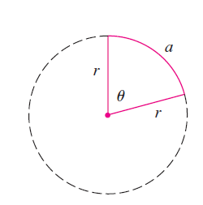

\begin{equation} \theta(rad)=\frac{a}{r} \end{equation}

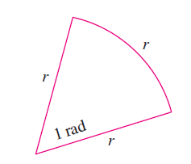

- $\pi~rad=180°$
- $1~ rad=180/\pi \sim 57°$.

**Correspondence between degree and radian measures of some common angles**

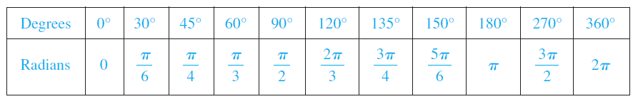

**Standart Position of an angle**

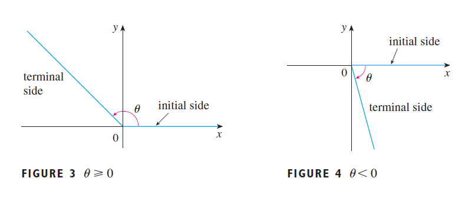

**Examples:**

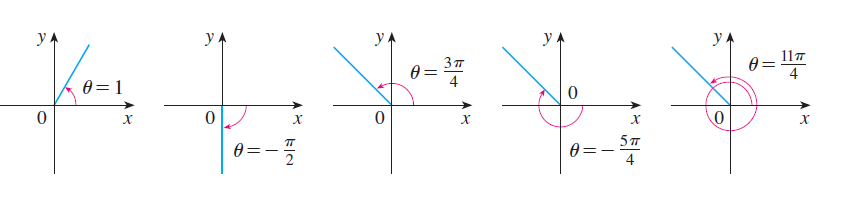

# The Trigonometric Functions

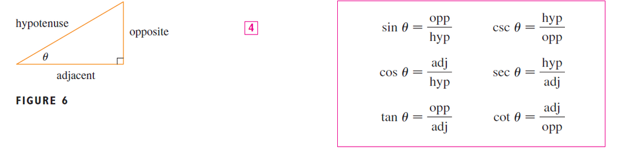

This definition doesn’t apply to obtuse or negative angles.

For a general angle in **standard position**...

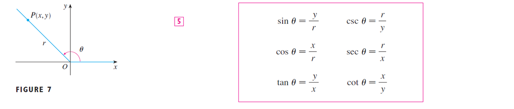

- sec and tan are undefined when $x=0$.
- csc and cot are undefined when $y=0$.

"**A**ll **S**tudents **T**ake **C**alculus" rule for signs

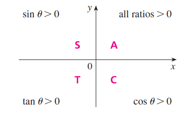

**Exact trigonometric ratios for certain angles**

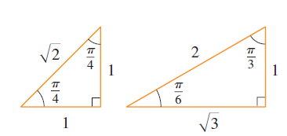

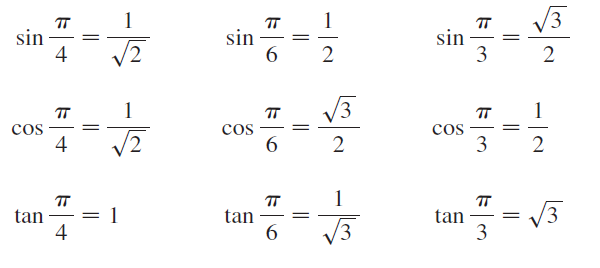

Most common angles:

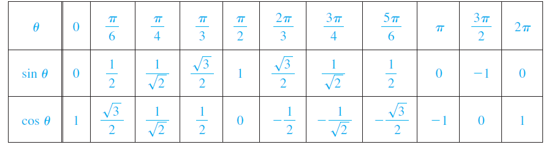

**Exercise 1**

Compute the values of the following trigonometrical functions according to the quadrant they belong to and using the table of “most common angles”:

1. $\cos(2\pi/3)$
2. $\cos(7\pi/6)$
3. $\sin(-5\pi/4)$
4. $\sin(5\pi/3)$

**Trigonometric identities**

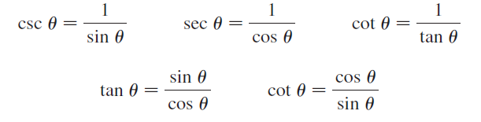

**Trigonometric identities**

1. $\sin^2\theta+cos^2\theta=1$
2. $\tan^2\theta+1=\sec^2\theta$
3. $1+\cot^2\theta=\csc^2\theta$

**Exercise 2**

1. Calculate all the trigonometric functions of the angle $\alpha$, given that $\cos\alpha=\sqrt{3}/2$, without computing α.
2. Calculate all the trigonometric functions of the angle $\alpha$, given that $\tan\alpha=3$, without computing α.

The identities:

- $\sin(-\theta)=-\sin(\theta)$
- $\cos(-\theta)=\cos(\theta)$

show that the sine is an **odd** function and cosine is an **even** function.

The identities:

- $\sin(\theta+2\pi)=\sin(\theta)$
- $\cos(\theta+2\pi)=\cos(\theta)$

show that the sine and cosine are periodic functions with period $T=2\pi$.

**Exercise 3**

Find the set of values of x that satisfies the equations:

1. $\sin(x)=1/2$
2. $\cos(x)=-\sqrt{3}/2$
3. $\sin(x)\cos(3x)+\cos(3x)\sqrt{2}/2$

**Sum and substraction of sin and cos**

1. $\sin(x+y)=\sin x\cos y+\cos x\sin y$
2. $\cos(x+y)=\cos x\cos y-\sin x\sin y$

Substituting $-y$ for $y$ in 1 and 2:

1. $\sin(x-y)=\sin x\cos y-\cos x\sin y$
2. $\cos(x-y)=\cos x\cos y+\sin x\sin y$

**Exercise 4**

Proof the following expressions:

1. $\sin2x=2\sin x\cos x$
2. $\cos2x=\cos^2x-\sin^2x$
3. $\cos2x=1-2\sin^2x$
4. $\cos2x=2\cos^2x-1$

# Graph of the Trigonometric Functions

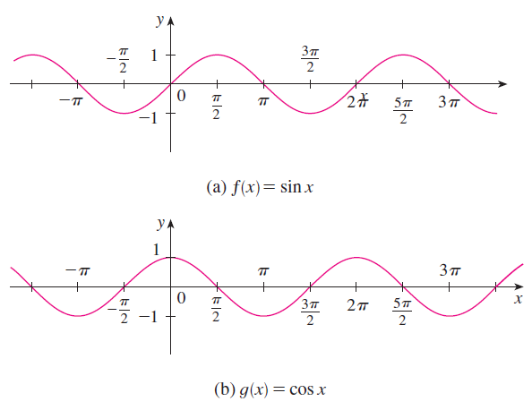

Properties:

- They are periodic $\rightarrow f(x+T)=f(x)$, where $T=2\pi$ is the period.
- Range: $[-1,1]$
- domain: $(-\infty,\infty)$
- zeros of $\cos(x)$: $(2n+1)\pi/2$, $n=...-1,0,1,2,3...$
- zeros of $\sin(x)$: $n\pi$, $n=...-1,0,1,2,3...$

In general, a sine or a cosine (an oscillation or a wave) is represented as $y=A\sin(\omega x+\theta )$ , where

- A is the amplitude and tell us about its range.
- $\omega$ is the frequency and tell us about its velocity of oscillation and its period.
- $\theta$ is the phase, and tell us about its delay.

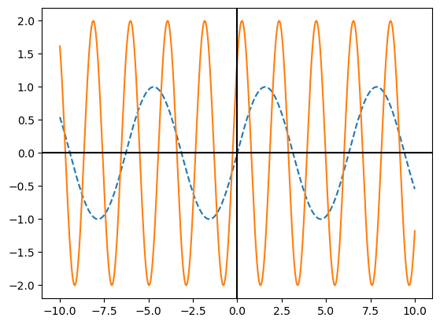

```python
import matplotlib.pyplot as plt

x=np.linspace(-10,10,1000)
A=2
w=3
theta=np.pi/4

plt.plot(x,np.sin(x),'--')
plt.plot(x,A*np.sin(w*x+theta))
plt.axhline(y = 0, color = 'k', linestyle = '-')
plt.axvline(x = 0, color = 'k', linestyle = '-')
# plt.legend(['$sin(x)$','$Asin(\omega x+\Theta)$'])
```

**Exercise 5**

Sketch the functions and find its zeroes, domain and range.

1. $y=\sin (2 x)$
2. $y=\sin ( x/3)$
3. $y=A\sin (3 x-\pi)$ (Final Spring 2018)
4. $y=\tan(x)$
5. $y=\sec(x)$
6. $y=\csc(x)$
7. $y=\csc(x/2-\pi)$

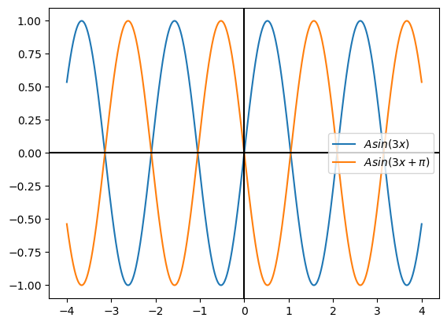

```python
#Check 3.
x=np.linspace(-4,4,1000)

A=1

plt.plot(x,A*np.sin(3*x))
plt.plot(x,A*np.sin(3*x-np.pi))
plt.axhline(y = 0, color = 'k', linestyle = '-')
plt.axvline(x = 0, color = 'k', linestyle = '-')
plt.legend(['$Asin(3x)$','$Asin(3x+\pi)$'])
```

**More Plots...**

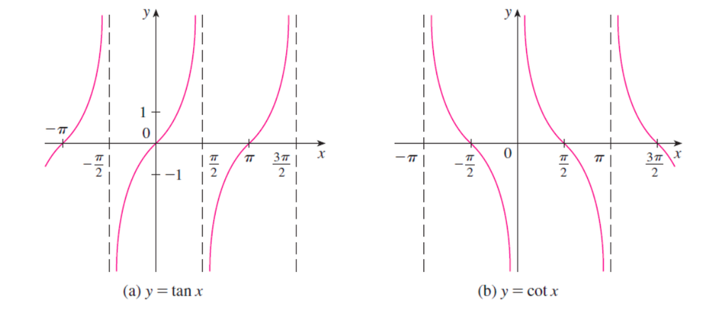

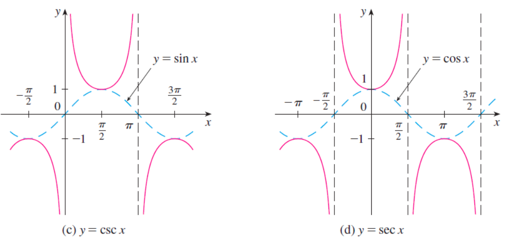

## Inverse trigonometric functions

- They are not one-to-one.
- We have to restrict the domain.

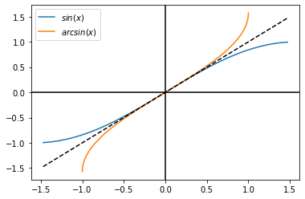

```python
import numpy as np
import matplotlib.pyplot as plt

x=np.linspace(-np.pi/2+0.1,np.pi/2-0.1,1000)
x1=np.linspace(-1,1,1000)

plt.plot(x,np.sin(x))
plt.plot(x1,np.arcsin(x1))
plt.plot(x,x,'--',color='k')

plt.axhline(y = 0, color = 'k', linestyle = '-')
plt.axvline(x = 0, color = 'k', linestyle = '-')

plt.legend(['$sin(x)$','$arcsin(x)$'])
```

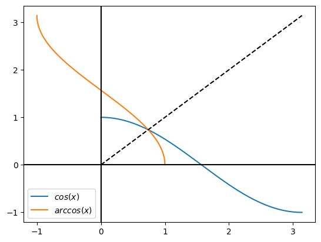

```python
x=np.linspace(0,np.pi,1000)
x1=np.linspace(-1,1,1000)

plt.plot(x,np.cos(x))
plt.plot(x1,np.arccos(x1))
plt.plot(x,x,'--',color='k')

plt.axhline(y = 0, color = 'k', linestyle = '-')
plt.axvline(x = 0, color = 'k', linestyle = '-')
plt.legend(['$cos(x)$','$arccos(x)$'])
```

**Exercise 6**

1. Sketch $y=\sin(2x-\pi)$ and $y=\arcsin(2x-\pi)$. Find their domain and range.
2. Sketch $y=\arctan (x /2)$ . Indicate its domain and range.
3. Find the inverse of $y=2\sec(3x-\pi)$ and sketch it. Indicate its domain. (Final Spring 2021)